# Case Study

Shanga Saadallah

2023-02-03

##Task statement Key stakeholders Urska Srsen Sando mur Finding trends in smart device usage, how could these apply to bellabeat and how they can help the marketing strategy for bellabeat products.

## Prepare data

Data source: kaggle Data format: Long format data Are data ROCCC: Reliability: This dataset is under CC0: Public Domain license meaning the creator has waive his right to the work under the copyright law. ## ROCCC analysis Reliability: LOW – dataset was collected from 30 individuals whose gender is unknown. Originality : LOW – third party data collect using Amazon Mechanical Turk. Comprehensive : MEDIUM – dataset contains multiple fields on daily activity intensity, calories used, daily steps taken, daily sleep time and weight record. Current : MEDIUM – data is 5 years old but the habit of how people live does not change over a few years Cited : HIGH – data collector and source is well documented ## Data Selection The data needed are daily usage of the smart device therefore there will be only the following files selected DailyActivities_merged.csv DailyCalories_merged.csv DailyIntensities_merged.csv DailySteps_merged.csv SleepDaily_merged.scv WeighLogInfo_merged.csv ## Prepare the data The data used in this analysis is the Fitbit Fitness Tracker Data made available by Mobius stored on Kaggle. This dataset is under CC0: Public Domain license meaning the creator has waive his right to the work under the copyright law. The data contains personal fitness tracker from thirty fitbit users. Thirty eligible Fitbit users consented to the submission of personal tracker data, including minute-level output for physical activity, heart rate, and sleep monitoring. It includes information about daily activity, steps, and heart rate that can be used to explore users’ habits. These datasets were generated by respondents to a distributed survey via Amazon Mechanical Turk between 03.12.2016-05.12.2016. The dataset has in total 18 files in .csv format organized in long format Process the data Google spreadsheet and Google BigQuery will be used to process the data as the tool functionality fits the purpose

## Data cleaning

sleepDay_merged.csv and weightLogInfo_merged.csv are loaded into Google Sheets for data cleaning. The fields “SleepDay” and “Date” were not correctly formatted. The following steps have been done: The date column has been selected and formatted to ‘Date’ using the spreadsheet function Time in the column has been removed as time is irrelevant in this analysis AM/PM indicator is also removed. ## Data integrity The selected data has been loaded into Google BigQuery for analysis. The following queries have been run to check the number of unique Id in each table:

SELECT DISTINCT Id FROM `my-capstone-case-study.smart_device.daily_activities` SELECT DISTINCT Id FROM `my-capstone-case-study.smart_device.daily_calories` SELECT DISTINCT Id FROM`my-capstone-case-study.smart_device.daily_intensities’ SELECT DISTINCT Id FROM`my-capstone-case-study.smart_device.daily_steps SELECT DISTINCT Id FROM `my-capstone-case-study.smart_device.sleep_day’ SELECT DISTINCT Id FROM`my-capstone-case-study.smart_device.weight_log`

Result(distinct Id in each table): 33 33 33 33 24 8 The result shows the dataset is inconsistent as we expect 30 unique IDs on all tables. The sleepDay_merged table and the weigthLogInfo_merged table have the highest inconsistencies with 6 and 22 inputs missing. This would affect the result of the analysis.

## Data analysis

### For finding activity level and calories burnt data in Bigquery

SELECT Id, ActivityDate, Calories, TotalSteps, TotalDistance, TrackerDistance, LoggedActivitiesDistance, (VeryActiveDistance+ModeratelyActiveDistance+LightActiveDistance) AS TotalActiveDistance, SedentaryActiveDistance, (VeryActiveMinutes+FairlyActiveMinutes+LightlyActiveMinutes) AS TotalActiveMinutes, SedentaryMinutes

FROM `my-capstone-case-study.smart_device.daily_activity`

### For finding relationship between activity level and sleep time

SELECT  
Activity.Id, ActivityDate, TotalDistance, TotalMinutesAsleep, TotalTimeInBed, TotalSteps, VeryActiveDistance, ModeratelyActiveDistance, VeryActiveMinutes, FairlyActiveMinutes, LightActiveDistance, SedentaryActiveDistance, LightlyActiveMinutes, SedentaryMinutes FROM `my-capstone-case-study.smart_device.daily_activity` As Activity INNER JOIN `my-capstone-case-study.smart_device.sleep_day` AS Sleep ON Activity.Id = Sleep.Id AND Activity.ActivityDate = Sleep.SleepDay

### For finding relationship between activiy and weight/BMI

SELECT

Activity.Id, ActivityDate, TotalDistance, TotalSteps, BMI, VeryActiveDistance, ModeratelyActiveDistance, VeryActiveMinutes, FairlyActiveMinutes, LightActiveDistance, SedentaryActiveDistance, LightlyActiveMinutes, SedentaryMinutes

FROM `my-capstone-case-study.smart_device.daily_activity` As Activity INNER JOIN `my-capstone-case-study.smart_device.weight_log` AS Weight ON Activity.Id = Weight.Id AND Activity.ActivityDate = Weight.Date ### Analysis

Load the packages.

```r
#install.packages("tidyverse", lib="C:/Users/Shange/AppData/Local/R/win-library/4.2")
#install.packages('skimr')
#install.packages('cowplot')
#install.packages("plotly")
#install.packages("ggplot2", lib="C:/Users/Shange/AppData/Local/R/win-library/4.2")
library(plotly)
library(tidyverse) #wrangle data
library(dplyr) #clean data
library(lubridate)  #wrangle date attributes
library(skimr) #get summary data
library(ggplot2) #visualize data
library(cowplot) #grid the plot
library(readr) #save csv
```

Prepaire the data

```r
setwd("D:/R/BellaBeat-Device")
daily_df <- read.csv("daily_activity.csv")
sleep_day <- read.csv("activity_sleep.csv")
weight <- read.csv("activity_weight.csv")
intensities <- read.csv("daily_intensities.csv")

daily_df <- daily_df%>%
  mutate( Weekday = weekdays(as.Date(ActivityDate, "%Y-%m-%d")))
sleep_day <- sleep_day%>%
  mutate( Weekday = weekdays(as.Date(ActivityDate, "%m/%d/%Y")))
merged_data <- merge(daily_df, weight, by = c("Id"), all=TRUE)
merged_data <- merged_data %>%
  mutate( Weekday = weekdays(as.Date(ActivityDate.x, "%m/%d/%Y")))
sleep <- read.csv("sleep.csv")
weight_log <- read.csv("weight_log.csv")
set1 <- merge(daily_df, weight_log, by = c("Id"), all=TRUE)
set2 <- merge(sleep, set1, by = c("Id"), all=TRUE)
awake <- mutate(set2, AwakeTime = TotalTimeInBed -TotalMinutesAsleep)
```

# Analysis

```r
set2 %>%
  dplyr::select(Weekday,
                TotalSteps,
                TotalDistance,
                VeryActiveMinutes,
                FairlyActiveMinutes,
                LightlyActiveMinutes,
                SedentaryMinutes,
                Calories,
                TotalMinutesAsleep,
                TotalTimeInBed,
                WeightPounds,
                BMI
  ) %>%
  summary()
```

```
##    Weekday            TotalSteps    TotalDistance    VeryActiveMinutes
##  Length:43482       Min.   :    0   Min.   : 0.000   Min.   :  0.00
##  Class :character   1st Qu.: 5899   1st Qu.: 3.910   1st Qu.:  0.00
##  Mode  :character   Median :10199   Median : 6.820   Median : 15.00
##                     Mean   : 9373   Mean   : 6.417   Mean   : 23.59
##                     3rd Qu.:12109   3rd Qu.: 8.350   3rd Qu.: 38.00
##                     Max.   :36019   Max.   :28.030   Max.   :210.00
##
##  FairlyActiveMinutes LightlyActiveMinutes SedentaryMinutes    Calories
##  Min.   :  0.00      Min.   :  0.0        Min.   :   0.0   Min.   :   0
##  1st Qu.:  3.00      1st Qu.:194.0        1st Qu.: 637.0   1st Qu.:1850
##  Median : 14.00      Median :238.0        Median : 697.0   Median :2046
##  Mean   : 17.82      Mean   :232.2        Mean   : 722.7   Mean   :2106
##  3rd Qu.: 31.00      3rd Qu.:288.0        3rd Qu.: 745.0   3rd Qu.:2185
##  Max.   :143.00      Max.   :518.0        Max.   :1440.0   Max.   :4900
##
##  TotalMinutesAsleep TotalTimeInBed   WeightPounds        BMI
##  Min.   : 58.0      Min.   : 61.0   Min.   :116.0   Min.   :21.45
##  1st Qu.:400.0      1st Qu.:421.0   1st Qu.:134.9   1st Qu.:23.89
##  Median :442.0      Median :457.0   Median :135.6   Median :24.00
##  Mean   :433.9      Mean   :458.3   Mean   :139.6   Mean   :24.42
##  3rd Qu.:477.0      3rd Qu.:510.0   3rd Qu.:136.7   3rd Qu.:24.21
##  Max.   :796.0      Max.   :961.0   Max.   :294.3   Max.   :47.54
##  NA's   :971        NA's   :971     NA's   :8974    NA's   :8974
```

The activities recorded were mostly concentrated in the days of tuesday, wednesday, and thursday. The records show that weekends are not the best activity days

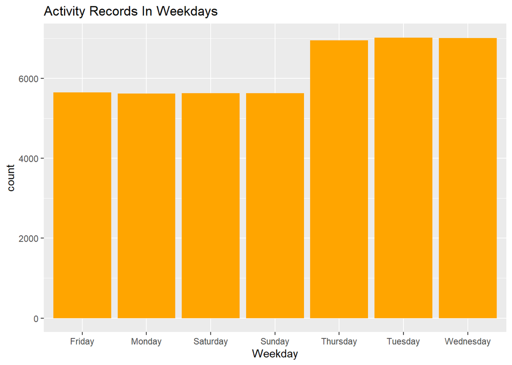

```r
library(ggplot2)
library(tidyverse)
ggplot(data=awake, aes(x=Weekday))+
  geom_bar(fill="Orange") +
  labs(title="Activity Records In Weekdays")
```

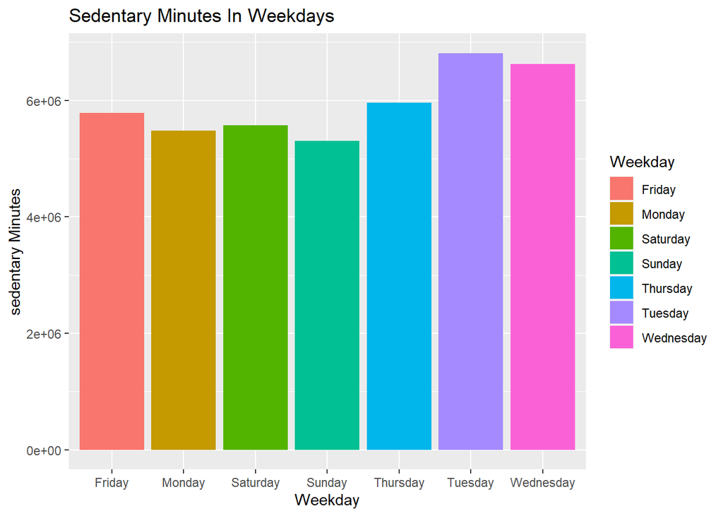

```r
library(ggplot2)
ggplot(data=awake, aes(x=Weekday, y=SedentaryMinutes+LightlyActiveMinutes, fill=Weekday))+
  geom_bar(stat="identity")+
  ylab("sedentary Minutes")+
  labs(title="Sedentary Minutes In Weekdays")
```

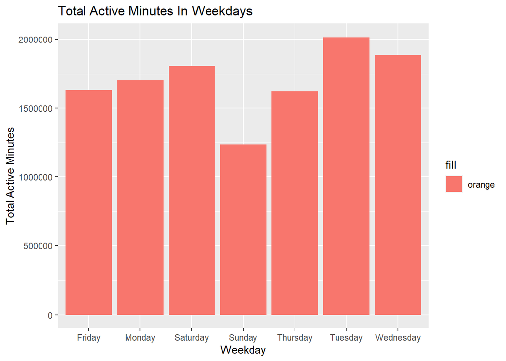

```r
ggplot(data=awake, aes(x=Weekday, y=VeryActiveMinutes+FairlyActiveMinutes+LightlyActiveMinutes, fill="orange"))+
  geom_bar(stat="identity")+
  ylab("Total Active Minutes")+
  labs(title="Total Active Minutes In Weekdays")
```

The user’s sleep was best on Tuesday, Thursday, and Wednesday, which is similar to the data records and this raised the question “how comprehensive are the data to form an accurate analysis?”

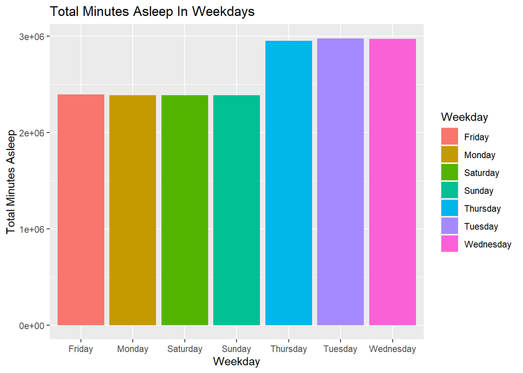

```r
ggplot(data=awake, aes(x=Weekday, y=TotalMinutesAsleep, fill=Weekday))+
  geom_bar(stat="identity")+
  ylab("Total Minutes Asleep")+
  labs(title="Total Minutes Asleep In Weekdays")
```

```r
#install.packages("ggpmisc")
library(ggpmisc)
```

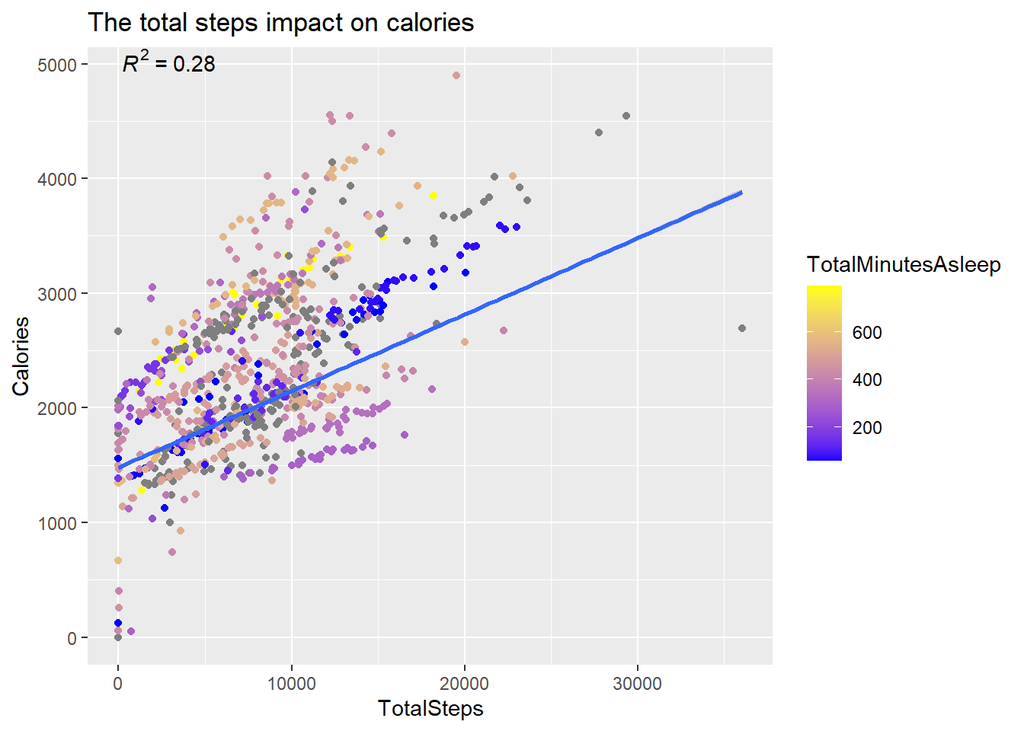

```r
par(mfrow = c(2, 2))
ggplot(data=awake, aes(x=TotalSteps, y=Calories, color=TotalMinutesAsleep))+
  geom_point()+
  stat_smooth(method=lm)+
  scale_color_gradient(low="blue", high="yellow")+
  labs(title="The total steps impact on calories")+
  stat_poly_eq(label.y = 400, aes(label = ..rr.label..))
```

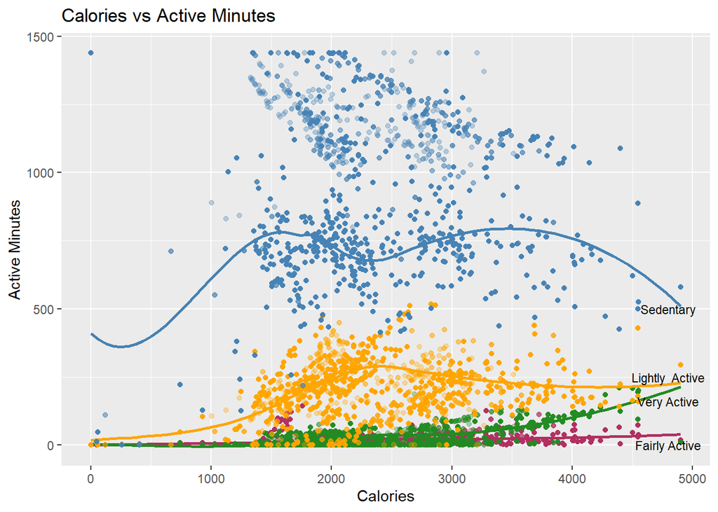

```r
ggplot(data = set2) +
  geom_point(mapping=aes(x=Calories, y=FairlyActiveMinutes), color = "maroon", alpha = 1/3) +
  geom_smooth(method = loess,formula =y ~ x, mapping=aes(x=Calories, y=FairlyActiveMinutes, color=FairlyActiveMinutes), color = "maroon", se = FALSE) +

  geom_point(mapping=aes(x=Calories, y=VeryActiveMinutes), color = "forestgreen", alpha = 1/3) +
  geom_smooth(method = loess,formula =y ~ x,mapping=aes(x=Calories, y=VeryActiveMinutes, color=VeryActiveMinutes), color = "forestgreen", se = FALSE) +

  geom_point(mapping=aes(x=Calories, y=LightlyActiveMinutes), color = "orange", alpha = 1/3) +
  geom_smooth(method = loess,formula =y ~ x,mapping=aes(x=Calories, y=LightlyActiveMinutes, color=LightlyActiveMinutes), color = "orange", se = FALSE) +

  geom_point(mapping=aes(x=Calories, y=SedentaryMinutes), color = "steelblue", alpha = 1/3) +
  geom_smooth(method = loess,formula =y ~ x,mapping=aes(x=Calories, y=SedentaryMinutes, color=SedentaryeMinutes), color = "steelblue", se = FALSE) +

  annotate("text", x=4800, y=160, label="Very Active", color="black", size=3)+
  annotate("text", x=4800, y=0, label="Fairly Active", color="black", size=3)+
  annotate("text", x=4800, y=500, label="Sedentary", color="black", size=3)+
  annotate("text", x=4800, y=250, label="Lightly  Active", color="black", size=3)+
  labs(x = "Calories", y = "Active Minutes", title="Calories vs Active Minutes")
```